# Do changes in environmental corporate sentiment correlate with changes in GHG levels?

FIRE Sustainability Analytics - Joshua Hildebrand, Sohum Desai, Abhinav Akenapalli 2024-01-01

# 1. Introduction

Understanding the impact of environmental corporate sentiment on changes in greenhouse gas emissions emphasizes the importance of environmental communication. By connecting how publicly traded companies communicate their environmental sentiment with changes in their operation’s greenhouse gas emissions, policymakers can better understand the impact of regulation that requires ecological reporting. This connection presents an opportunity to encourage companies to reduce their greenhouse gas emissions and show society their corporate environmental sentiment in their annual 10-K reports. This type of communication will become more important as countries factor pollution output into the costs of production to clean domestic manufacturing. It will also further our knowledge on differentiating honest environmental sentiment that is acted upon as reflected by their pollution levels compared to “cheap talk” (Bingler et al., 2024). Through our data, we hold companies more accountable for their communications of their environmental impacts. By examining greenhouse gas emissions reported to the EPA’s FLIGHT database, we can narrow our focus to directly connecting a company’s sentiment of their pollution to the actual emissions they generate. We can focus on this sentiment through closely examining the 10-K reports of these companies in order to detect their environmental sentiment compared to their actual greenhouse gas emission output.

Our research boils down to three main parts. We had three main data sources which starts with the EPA Flight data to rack the greenhouse gas emissions from large facilities. Then, we have the SEC EDGAR 10-k reports which captures the communications made by these companies, and ClimateBERT which is utilized to classify environmental sentiment present in these communications. We started with 11,000 companies from the FLIGHT data which was then narrowed down to 100 publicly traded companies that had 13 years worth of emissions data and 10-k filing statements. Lastly, using ClimateBERT’s net-zero/reduction model we were able to classify these sentences and compare this with the greenhouse gas emission data we have.

# 2. Literature Review

- Presently, much work has been done on discerning genuine climate commitments and ‘cheap talk’. Current research concludes that firms with poor environmental action tend to communicate more environmental goals to “distract from poor performance” (Preuss & Max, 2023). This study focused on firms that were a part of the S&P 500 betwen 2010 and 2020. The reasoning behind this is that firms part of The S&P 500 were more likely to issue sociopolitical statements and are more likely to have political action committee (PAC) contributions compared to smaller firms (Preuss & Max, 2023). This means that policies that intend to generate environmental commitments need to require clarity from companies if they want genuine environmental communications from companies.
- Identifying specific and genuine environmental communications has been done through ClimateBERT’s environmental claims detection model. Given Preuss & Max’s large data set of annual reports, shareholder preposals, and press releases, they decided to not manually verify if each statement contained a keyword, but instead they focused on generating n-grams which were 2-4 words in length. From here the study generated measures of sociopolitical claims per topic. Both of these measurements were based on the frequency of these n-grams within the sample data. The first measure was the number of times any n-gram appeared in the corporate filings data they collected and the second measure docs counted the number of documents per year that included two distinct environmental related n-grams. These measurements were the foundation to the conclusions and claims of the study.
- Our research uses the zero-emissions BERT large language model created by (Bingler et al. 2024), to detect sentences with planned GHG reduction sentiments and combine the output with GHG emissions to evaluate if a company’s pollution reflects their sentiment. The zero-emissions BERT large language model is a fine-tuned ClimateBERT language model with a classification head for detecting sentences that are either related to emission net zero or reduction targets. There are multiple studies that have utilized the climateBERT large language model, specifically a study completed by Bingler, relating Task Force on Climate-Related Financial Disclosures (TCFD) recommendations with the impact on disclosures of TCFD-supporting companies. This study is similar to ours, and utilized climateBERT to analyze the disclosures of TCFD-supporting firms. The model found “that the firms’ TCFD support is mostly just talk and that these firms cherry-pick to report primarily non-material climate risk information” (Bingler et al. 2022).
- Our research scans corporate communications from companies for sentences containing emissions information and changes in their corresponding pollution measured by the government. By examining these two variables we will see if companies support their environmental claims through changes in their emission levels.

# 3 Data

## 3.1 FLIGHT

The EPA FLIGHT data set shows our outcome variable which is the greenhouse gas (GHG) emissions for large facilities. Using this data set, the environmental impact of each company can be quantified. In order to match these companies, to 10-K reports, the company list from FLIGHT is fed into Chat GPT. The intuition is simple: companies that can be associated with a stock ticker will be in the SEC EDGAR database. For this reason, 11,000 companies were fed into CHAT GPT to determine if each company had a ticker. The output was each company’s name and a stock ticker or N/A if a ticker was not found. Chat GPT found 2578 companies with a ticker. Using a string distance library, the Chat GPT output was merged with FLIGHT data to link GHG emissions with these tickers. The string distance library was used to narrow down companies that were repeats or companies that were not even in FLIGHT that Chat GPT may have unintentionally added. Next, the number of years for each company was examined. To keep data uniform and allow for the most specific data, it was determined that only companies with 13 years of data will be used in our data. The final result is 100 companies that will be referenced in SEC EDGAR. Relating the GHG emissions from these companies from the past 13 years to corporate sentiment from SEC EDGAR 10-K reports, a score can be determined for each company.

## 3.2 SEC EDGAR

10-K documents summarize a company’s financial performance and other important information including their environmental and emissions activity. By scraping the SEC EDGAR database, 10-K reports were collected for our geographic unit, each company, for a frequency of each year for the past 13 years and then parsed by sentence to create a data collection of spreadsheets containing each sentence from each 10-K. After gathering companies from the FLIGHT database, we filtered the companies to only consider ones that are publicly traded. This ensures that they will be in the SEC EDGAR database since this database only has companies that are publicly traded. This task produced one spreadsheet of sentences for the past 13 years for each of the 100 FLIGHT companies yielding 1,300 spreadsheets.

```r
library('tidyverse')
library('data.table')
library('rvest')
library('httr')

symbol_table <- as.data.frame(read.csv('unique_tickers_only.csv'))
symbol<-read.csv('flight_tickers.csv', header = TRUE) |>
  filter(!str_detect(x,"N/A")) |>
  filter(!str_detect(x, " ")) |>
  filter(!str_detect(x,"\\."))


try_scrape_parse <- function(i){
  tryCatch({

url <- paste0("http://www.sec.gov/cgi-bin/browse-edgar?action=getcompany&CIK=",
              symbol$x[i], "&type=10-k&dateb=&owner=exclude&count=100")

# Scrape filing page identfier numbers
response <- GET(url,add_headers(
  "User-Agent" = "Mozilla/5.0 (Windows NT 10.0; Win64; x64) AppleWebKit/537.36 (KHTML, like Gecko) Chrome/91.0.4472.124 Safari/537.36",
  "Accept-Language" = "en-US,en;q=0.5",
  "Accept" = "text/html,application/xhtml+xml,application/xml;q=0.9,image/webp,*/*;q=0.8",
  "Accept-Encoding" = "gzip, deflate, br",
  "Referer" = "https://www.sec.gov/",
  "Connection" = "keep-alive",
  "DNT" = "1",  # Do Not Track
  "Upgrade-Insecure-Requests" = "1"))
if (status_code(response) == 200) {
  company_info <-
    read_html(response) %>%
    html_nodes(xpath='//*[@id="contentDiv"]/div[1]/div[3]/span/a')
  #html_table() %>%
  #as.data.table() %>%
  #janitor::clean_names()
  cik_number <- sub(".*CIK=(\\d{10}).*", "\\1", company_info)
} else {
  print(paste("Failed to retrieve 1st Response page. Status code:", status_code(doc)))
}
if (status_code(response) == 200) {
  filings <-
    read_html(response) %>%
    html_nodes(xpath='//*[@id="seriesDiv"]/table') %>%
    html_table() %>%
    as.data.table() %>%
    janitor::clean_names()
} else {
  print(paste("Failed to retrieve 1st Response page. Status code:", status_code(doc)))
}

# Drop pre XBRL filings
filings <- filings[str_detect(format, "Interactive")]

# Extract filings identifiers with regex match of digits
pattern <- "\\d{10}\\-\\d{2}\\-\\d{6}"
filings <- filings$description
filings <-
  stringr::str_extract(filings, pattern)

# Build urls for filings using filing numbers and Edgar's url structure
urls <-
  sapply(filings, function(filing) {

    # Rebuild URL to match Edgar format
    url <-
      paste0(
        "https://www.sec.gov/Archives/edgar/data/",cik_number,"/",
        paste0(
          str_remove_all(filing, "-"),"/"),
        paste0(
          filing, "-index.htm"),
        sep="")

    # Return Url
    url
  })
# Extract hrefs with links to 10-K filings
aapl_href <-
  sapply(urls, function(url) {

    # Pattern tomatch
    href <- '//*[@id="formDiv"]/div/table'
    response <- GET(url,add_headers(
      "User-Agent" = "Mozilla/5.0 (Windows NT 10.0; Win64; x64) AppleWebKit/537.36 (KHTML, like Gecko) Chrome/91.0.4472.124 Safari/537.36",
      "Accept-Language" = "en-US,en;q=0.5",
      "Accept" = "text/html,application/xhtml+xml,application/xml;q=0.9,image/webp,*/*;q=0.8",
      "Accept-Encoding" = "gzip, deflate, br",
      "Referer" = "https://www.sec.gov/",
      "Connection" = "keep-alive",
      "DNT" = "1",  # Do Not Track
      "Upgrade-Insecure-Requests" = "1"))

    if (status_code(response) == 200) {
      # Table of XBRL Documents
      page <-
        read_html(response) %>%
        xml_nodes('.tableFile') %>%
        html_table()
    } else {
      print(paste("Failed to retrieve 2nd Response page. Status code:", status_code(response)))
    }

    # Extract document
    page <- rbindlist(page)
    document <-
      page[str_detect(page$Type, "10-K")]$Document

    # Take break not to overload Edgar
    Sys.sleep(2)

    # Reconstite as href link
    href <-
      paste0(str_remove(url, "\\d{18}.*$"),
             str_extract(url, "\\d{18}"),
             "/",
             document)
    href <- href %>%
      str_replace_all('iXBRL', '') %>%
      str_trim()

    # Return
    href

  })

aapl_href <- lapply(aapl_href, function(x) {
  result <- x[str_detect(x, "htm$")]
  if (length(result) == 0) character(0) else result
})

# Show first 5 hrefs
#aapl_href[1:5]
#dir.create('AAPL_Scraped_Parsed')

for( j in 1:length(aapl_href)){
  response <- GET(as.character(aapl_href[j]),add_headers(
    "User-Agent" = "Mozilla/5.0 (Windows NT 10.0; Win64; x64) AppleWebKit/537.36 (KHTML, like Gecko) Chrome/91.0.4472.124 Safari/537.36",
    "Accept-Language" = "en-US,en;q=0.5",
    "Accept" = "text/html,application/xhtml+xml,application/xml;q=0.9,image/webp,*/*;q=0.8",
    "Accept-Encoding" = "gzip, deflate, br",
    "Referer" = "https://www.sec.gov/",
    "Connection" = "keep-alive",
    "DNT" = "1",  # Do Not Track
    "Upgrade-Insecure-Requests" = "1"))

  if (status_code(response) == 200) {
    # Table of XBRL Documents
    doc <- read_html(response)

  } else {
    print(paste("Failed to retrieve Response3 page. Status code:", status_code(response)))
  }


  # Using read_html(response)
  paragraphs<-doc %>%
    rvest::html_nodes("p, div") %>%
    rvest::html_text()

  textfile<-str_split(paragraphs,
                      "(?<!\\b(?:Mrs|Mr|Dr|Inc|Ms|Ltd|No|[A-Z])\\.)(?<=\\.|\\?|!)\\s+",
                      simplify = TRUE)
  textfile <- matrix(paste(textfile))
  p<-as.data.frame(textfile)

  p2<-p %>%
    mutate(charlength=nchar(V1)) %>%
    mutate(first=substr(V1, 1, 1)) %>%
    filter(str_detect(first, "^[A-Z]")) %>%
    mutate("White spaces" = str_count(V1, " ")) %>%
    mutate("Non-breaking space character" = str_count(V1, "\u00A0"))

  p3<-p2 %>%
    filter(`Non-breaking space character`<20)%>%
    filter(`charlength` > 30 & str_ends(V1,"\\.")) %>%
    select(V1)

  filename <- unlist(str_split(names(aapl_href[j]), "-"))[2]
  write.csv(p3,
            paste0("G:/Shared drives/2024 FIRE-SA/DATA/Companies_Scraped(2)/",
                       symbol$x[i], "_", filename, ".csv"))
}
},
  error = function(e){
    message(paste0("An error occurred at ", i," ", symbol$x[i]))
    print(e)
  },
  warning = function(w){
    message(paste0("A warning occurred at ", i, " ", symbol$x[i]))
    print(w)
    return(NA)
  })
}
for (i in 2:nrow(symbol)) {
  try_scrape_parse(i)
}
try_scrape_parse(1)
```

## 3.3 BERT

# 4. Summary

## 4.1 Data Cleansing Chart

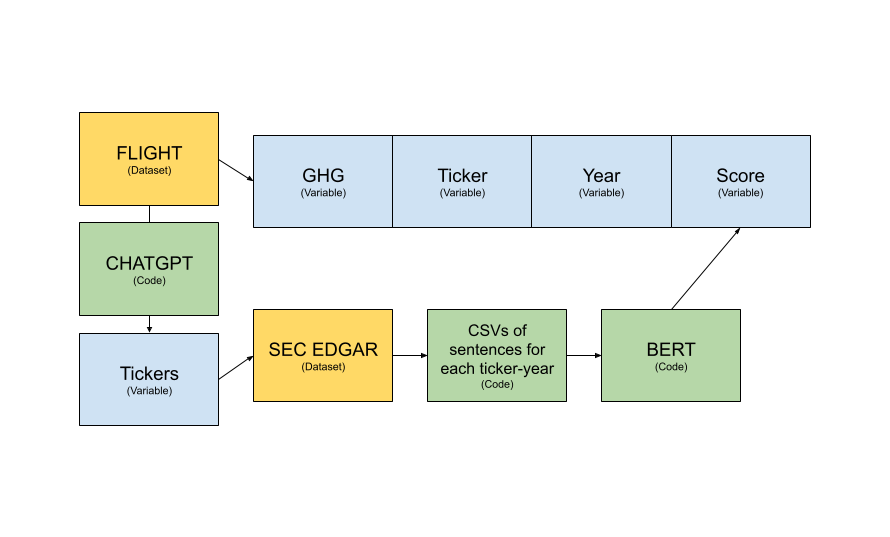

Data Cleansing Chart

Only publicly traded companies are required to report 10-K statements. Thus, we parsed through each company in our EPA FLIGHT company list to generate tickers only for that companies were publicly traded and therefore have reported 10-K statements. From here we were able to then scrape the SEC EDGAR collect data and create a csv file containing the broken down 10-K statement’s sentences for each ticker-year. These csv files were then process through the BERT net zero reduction model to identify emission reduction sentences. Lastly we generate scores by computing ratio of reduction sentences to total sentences in the 10-K report and connected them to the quantity of GHG emissions for each year as reported on EPA FLIGHT database.

## 4.2 Plot

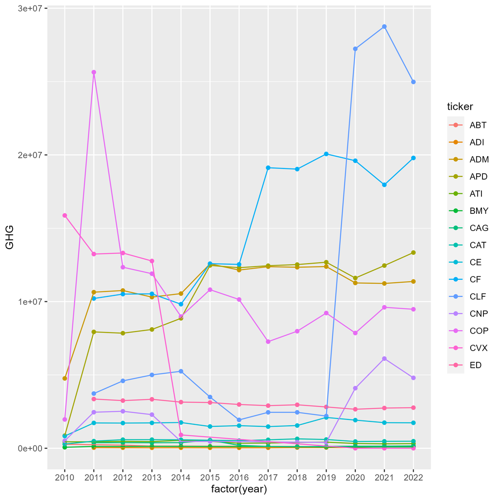

This plot shows the GHG per year for each of the 15 companies.

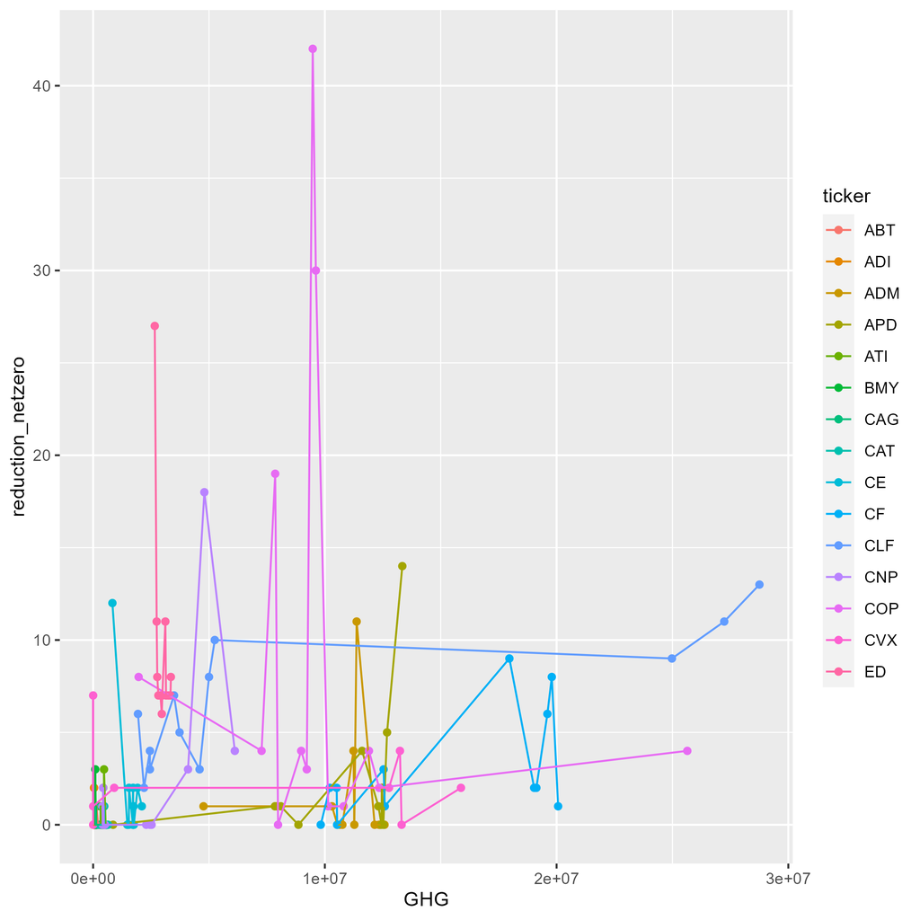

This plot shows the number of reductions according to each GHG value for each of the 15 companies.

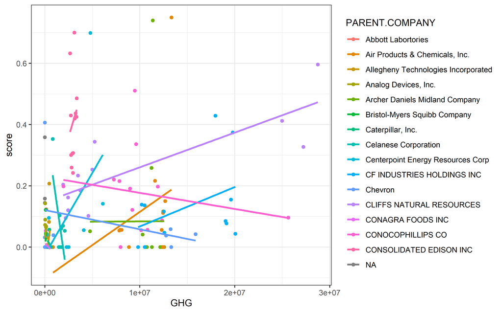

This plot shows the relationship between corporate sentiment and GHG emissions for each company.

## 4.3 Empirical Analysis and Linear Regression

### Empirical Analysis

Our research examined the relationship between environmental corporate sentiment and greenhouse gas emissions utilizing the following model. Note, this is a simiplified version of what our research looked like to give a glimpse into how we achieved our results.

```
Sentiment_Score(i,t) = (Reduction_Sentences(i,t) + NetZero_Sentences(i,t)) / Total_Sentences(i,t)
where:
i = company identifier
t = year (2010-2022)
Reduction_Sentences = sentences classified as containing emission reduction commitments
NetZero_Sentences = sentences classified as containing net-zero targets
```

To analyze the relationship between sentiment and emissions, we estimate:

[output not shown]

The sentiment score for each company-year observation is calculated as the ratio of sentences classified by ClimateBERT as either emission reduction or net-zero commitments to total sentences in the 10-K report. GHG emissions are measured in metric tons of CO2 equivalent as reported to EPA FLIGHT.

### Linear Regression Summary

```r
library('tidyverse')
library('fixest')
df<-read.csv("finaldata.csv")

df2<-df |>
  mutate(score=(reduction+netzero)*100/sentences) |>
  mutate(PARENT.COMPANY=ifelse(str_detect(PARENT.COMPANY, "Chevron"), "Chevron", PARENT.COMPANY))
m1<-feols(GHG ~ score:as.factor(ticker) | ticker + year, data=df2)
summary(m1)
```

```
OLS estimation, Dep. Var.: GHG
Observations: 195
Fixed-effects: ticker: 15,  year: 13
Standard-errors: Clustered (ticker)
                             Estimate Std. Error   t value   Pr(>|t|)
score:as.factor(ticker)ABT 11015617.0    7032441  1.566400 1.3957e-01
score:as.factor(ticker)ADI  1006307.8   11561987  0.087036 9.3188e-01
score:as.factor(ticker)ADM  -575054.5    1242152 -0.462950 6.5051e-01
score:as.factor(ticker)APD  5063034.2    1816499  2.787248 1.4541e-02 *
score:as.factor(ticker)ATI -6625038.8    6270115 -1.056606 3.0858e-01
score:as.factor(ticker)BMY -6547807.0    5844456 -1.120345 2.8142e-01
score:as.factor(ticker)CAG -5801834.4   15110025 -0.383973 7.0677e-01
score:as.factor(ticker)CAT -6523751.3   12836426 -0.508222 6.1921e-01
score:as.factor(ticker)CE   2977058.6    4321171  0.688947 5.0212e-01
score:as.factor(ticker)CF  18430294.5    2608069  7.066643 5.6242e-06 ***
score:as.factor(ticker)CLF 61671107.3    1819253 33.899132 7.7067e-15 ***
score:as.factor(ticker)CNP  4577781.3    1659530  2.758481 1.5387e-02 *
score:as.factor(ticker)COP -8357158.9    1719811 -4.859349 2.5280e-04 ***
score:as.factor(ticker)CVX -6210008.3    2206426 -2.814510 1.3781e-02 *
score:as.factor(ticker)ED    -50255.1    1035133 -0.048549 9.6196e-01
---
Signif. codes:  0 '***' 0.001 '**' 0.01 '*' 0.05 '.' 0.1 ' ' 1
RMSE: 2,913,161.3     Adj. R2: 0.713618
                    Within R2: 0.369347
```

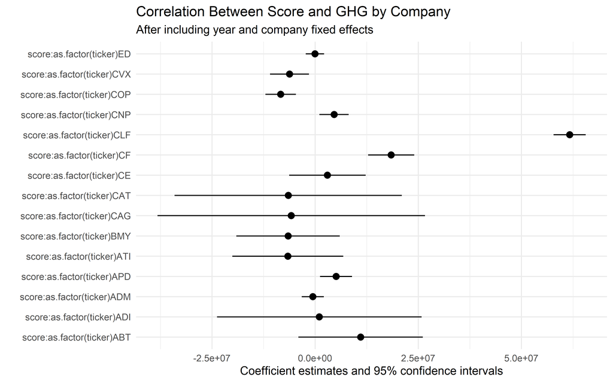

This graph shows 95% confidence intervals for the correlation between corporate sentiment and GHG emissions for each company.

# 5. Discussion

## 5.3 Mechanisms

There are various mechanisms that drive this correlation between corporate sentiment and GHG emissions detailed below. 1. Implementation Timeline - It takes time for changes to be reflected once they are announced. For example, if a given plan is announced it may take an entire year for the change to be reflected in the data. 2. Mergers and Acquisitions - When companies merge or are acquired by others, there can be an effect in the emission measurement. Relocation also plays a factor in emissions measurements whether it could be an increase, decrease, or loss of data.

## 5.4 Literature Context

# 6. Future Plans

Our future plans for this project are vast, but some ways that we can proceed have been detailed below.

1. Industry Specific Research
   - Moving forward we could analyze sector specific patterns, and see if different sectors have different correlations between GHG and corporate sentiment
2. Increased Timeframe and Firms
   - This data processing handling requires a lot of computing power, so with some more powerful computing resources we may be able to expand our research across many more firms and years, ultimately making our findings more reliable.
3. Policy Influence
   - Another way to move forward includes researching more about policy changes and how they effect corporate sentiment. How effective are current disclosure policies? Do changes in these policies also change corporate sentiment?

# 7. References

- Bingler, J., Kraus, M., Leippold, M., & Webersinke, N. (2022). How cheap talk in climate disclosures relates to climate initiatives, corporate emissions, and reputation risk. Swiss Finance Institute Research Paper, (22-01)
- Preuss, S., & Max, M. M. (2023). Do firms put their money where their mouth is? Sociopolitical claims and corporate political activity. Accounting, Organizations and Society, 101510
- ChatClimate - About. (n.d.). Frigg.eco. https://www.chatclimate.ai/climatebert
- Bingler, J., Kraus, M., Leippold, M., & Webersinke, N. (2022). Cheap talk and cherry-picking: What ClimateBert has to say on corporate climate risk disclosures. Sciencedirect Research Paper, (22-01)